# BTO Bird Ringing & Mothing Apps

Stephen H. Vickers

## Introduction

I have developed a range of tools aimed at ringers to help explore your data beyond what is currently available in DemOn, reduce workload on colour ring scheme co-coordinators, and assist in exploring annual BTO ringing report data. Many of the apps listed below require DemOn output files. These apps are not officially affiliated with the BTO, and have been developed independently.

I have also developed an app aimed at exploring trends in your Moth observation data. Primarily aimed at user of UK lepidoptera webpages but can be used by all.

Recommendations for new apps, or improvements to the current apps are welcomed. Email me: sjedwards94@hotmail.co.uk or find me on Twitter: https://twitter.com/Stephen8Vickers

## Controls and Recoveries Plotter

Take the control/recovery reports provided by DemOn (as a .html file), upload them here and get yourself a nice map. Simple!

### https://stephenvickers.shinyapps.io/conrecplotter/

[figure not shown]

## Within-group Between-site Movements Finder

Take the default raw data output from DemOn (as a .csv file), upload it here and discover all those movements of birds between your own sites that you’ve been missing. You’ll even get a map as a bonus.

### https://stephenvickers.shinyapps.io/siteinterchange/

[figure not shown]

## Within-group Longevity Finder

Take the default raw data output from DemOn (as a .csv file), upload it here and discover your longest lived birds of each species. National records are also available so you can see how your birds measure up.

### https://stephenvickers.shinyapps.io/group_longevity/

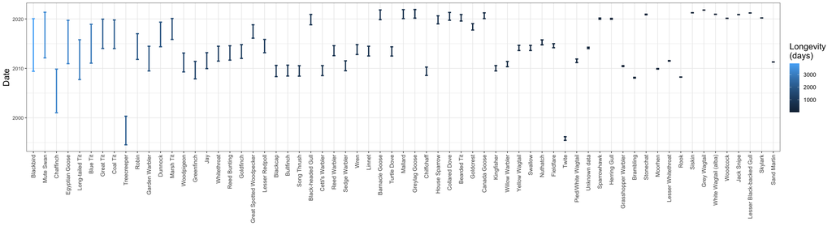

## Annual Ringing and NRS Report Trend Plotter

The BTO produce an annual report detailing the number of birds ringed and nest records submitted across Britain & Ireland. This app allows you to explore trends in these numbers over time and between regions.

### https://stephenvickers.shinyapps.io/ringing_totals/

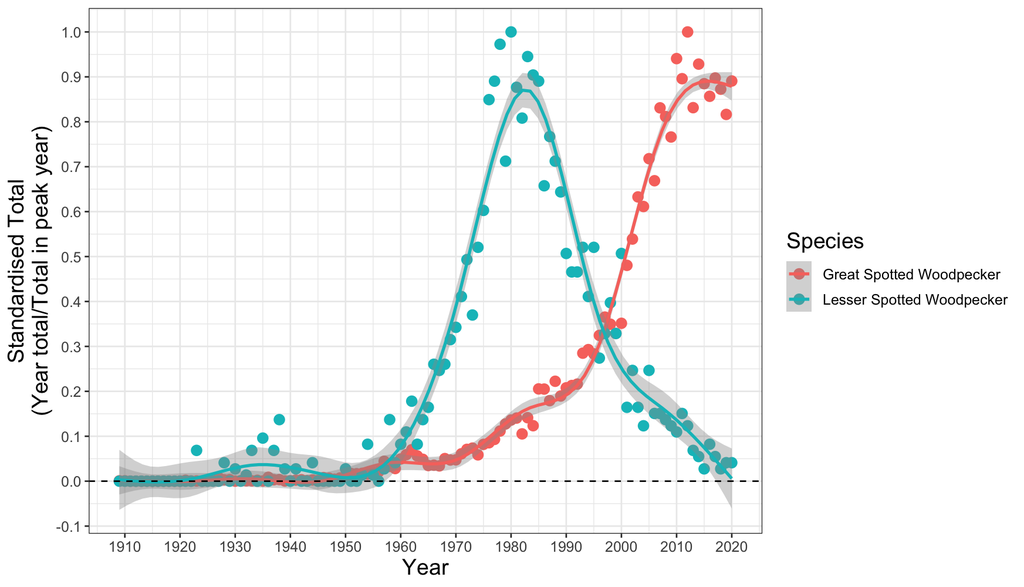

## Annual Ringing Report Map Plotter

The BTO produce an annual report detailing the number of birds ringed and nest records submitted across Britain & Ireland. This app allows you to explore how these numbers differ spatially in an interactive map.

### https://stephenvickers.shinyapps.io/ringing_map/

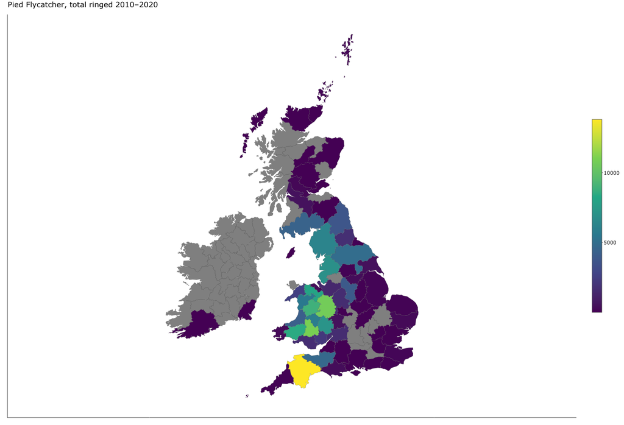

## Automated Colour-ring Reporting Websites

Colour ring project leads spend plenty of time responding to sightings and building life histories of their birds to do so. These apps are built bespoke for each project lead to collect the data required from reporters and automatically give them a full life history of the bird they sighted instantly on submission. No more waiting around for an email reply for reporters, and that time pressure and workload is greatly reduced for project leads.

Here are links to my current active apps, get in contact if you would like your own:

#### https://stephenvickers.shinyapps.io/swansubapp/

#### https://mid-walesrg.shinyapps.io/mwrg_sightings/

#### https://waterbirdcolourmarking.shinyapps.io/sightings/

#### https://westcornwallrg.shinyapps.io/sightings/

#### https://projectpenelope.shinyapps.io/sightings/

## DemOn AutoUploader

BTO’s ringing data repository Demography Online (DemOn) does not currently have batch upload capabilities unlike its predecessor IPMR. Joel Pick developed a system to do this in DemOn using Docker and R. With his permission I have developed upon his system to increase available data entry fields, add a new function aimed at entry of sightings data, and incorporated several more minor tweaks to the code.

Code and an in-depth user guide can be found on my GitHub here: https://github.com/SHVickers94/DemOn_Autouploader

[figure not shown]

## Visualise your moth-recording stats

Explore trends in your moth observations. This app is primarily aimed at users of UK Lepidoptera webpages such as norfolkmoths.co.uk, suffolkmoths.co.uk, or cambsmoths.co.uk but the data format required can be emulated easily for those that use other systems.

### https://stephenvickers.shinyapps.io/mothing_vis/

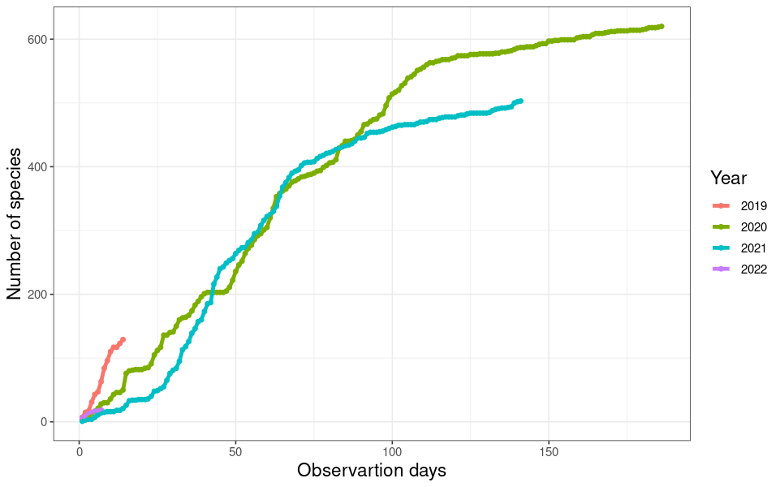